# Activity Prediction Model from personal fitness device data

Syed Abdullah Hasan

8/15/2021

# Executive Summary

This project examines data from personal fitness devices to develop a machine learning model and predict outcomes for a test set. The data used herein covers five cases of exercise being conducted by participants. Exploratory analysis is used to determine preprocessing requirements for the data set and develop preliminary classification based on clustering techniques. Subsequently, several machine learning models have been developed of which random forests generate the best results as evaluated on in-sample and out-of-sample predictive accuracy. Predictions on twenty cases of test data are subsequantly provided.

### 1. Pre-processing Methodology

The raw data set includes a total of 19622 observations for 160 variables. The outcome variable includes 5 levels, for which observations are distributed as follows:

| Outcome | Observations |
| --- | --- |
| A | 5,580 |
| B | 3,797 |
| C | 3,422 |
| D | 3,216 |
| E | 3,607 |

The following transformations have been made to clean and prepare the data for processing:

1. Outcome variable is converted to a numeric factor variable with levels A-E corresponding to numbers 1-5. This will facilitate exploratory analysis and model building.
2. Metadata variables corresponding to columns 1-7 have been removed from the data sets.
3. Character variables other than the outcome variable are all converted to numeric format.
4. Some variables include missing values in over 97% of observations - any variables with over 90% of values missing are excluded.
5. Covariates with near-zero variation have been removed.
6. Covariates with high pair-wise correlations are also removed.

Subsequently, the data is is partitioned into training (70%) and test (30%) sets.

The final distribution of observations between data sets is as follows:

| Dataset | Observations |
| --- | --- |
| Test | 5,885 |
| Train | 13,737 |

### 2. Exploratory Analysis

##### 2.1 Clustering Analysis

Clustering techniques can be used to segregate outcomes based on all predictors for possible use in unsupervised learning models. Hierarchical and K-Means clustering results are shown in the appendices for reference. We note that hierarchical clustering delivers an accuracy of 28.66% whereas K-means clustering delivers an accuracy of 28.87%

### 3. Model Building and Selection

We now proceed to build and compare several models to classify the outcome variable in the data set.

##### 3.1. Cross-Validation Parameters

In order to obtain the best assessment of out-of-sample performance for the models, a k-fold cross validation approach is set for all models. The k-fold cross validation method involves splitting the dataset into k-subsets. Each subset is held out while the model is trained on all other subsets. This process is completed until accuracy is determined for each instance in the dataset, and an overall accuracy estimate is provided. A 10-fold cross validation approach is used here.

##### 3.2. Model Fitting

When fitting each model, accuracy is used as the primary assesment criteria of model performance since we are working with a classification problem. Accuracy is determined for in-sample (train) and out-of-sample (test) data.

##### 3.3. Model Performance Summary

|  | Model | Accuracy…In.Sample | Accuracy…Out.of.Sample |
| --- | --- | --- | --- |
| 1 | Decision Trees | 0.56 | 0.55 |
| 2 | Random Forests | 1.00 | 0.99 |
| 3 | Linear Discriminant Analysis | 0.59 | 0.58 |
| 4 | Regularized Regression - Ridge | 0.38 | 0.37 |
| 5 | Regularized Regression - Lasso | 0.28 | 0.28 |

The above table shows a summary of performance for each model. We can observe that the Random Forest model is able to achieve an in-sample accuracy of 1 and out-of-sample accuracy of 0.988955 which significantly exceeds the performance of all other models. Secondly, the accuracy implies very high predictive power, due to which we do not need to consider further steps in developing a blended model.

To prepare the predicted classifications on the test data, the same transformations are carried out as before with the training data.

| Problem.ID | Predicted.Class |
| --- | --- |
| 1 | B |
| 2 | A |
| 3 | B |
| 4 | A |
| 5 | A |
| 6 | E |
| 7 | D |
| 8 | B |
| 9 | A |
| 10 | A |
| 11 | B |
| 12 | C |
| 13 | B |
| 14 | A |
| 15 | E |
| 16 | E |
| 17 | A |
| 18 | B |
| 19 | B |
| 20 | B |

# Appendices

### 1. Data Structure

```
## 'data.frame':    19622 obs. of  160 variables:
##  $ X                       : int  1 2 3 4 5 6 7 8 9 10 ...
##  $ user_name               : chr  "carlitos" "carlitos" "carlitos" "carlitos" ...
##  $ raw_timestamp_part_1    : int  1323084231 1323084231 1323084231 1323084232 1323084232 1323084232 1323084232 1323084232 1323084232 1323084232 ...
##  $ raw_timestamp_part_2    : int  788290 808298 820366 120339 196328 304277 368296 440390 484323 484434 ...
##  $ cvtd_timestamp          : chr  "05/12/2011 11:23" "05/12/2011 11:23" "05/12/2011 11:23" "05/12/2011 11:23" ...
##  $ new_window              : chr  "no" "no" "no" "no" ...
##  $ num_window              : int  11 11 11 12 12 12 12 12 12 12 ...
##  $ roll_belt               : num  1.41 1.41 1.42 1.48 1.48 1.45 1.42 1.42 1.43 1.45 ...
##  $ pitch_belt              : num  8.07 8.07 8.07 8.05 8.07 8.06 8.09 8.13 8.16 8.17 ...
##  $ yaw_belt                : num  -94.4 -94.4 -94.4 -94.4 -94.4 -94.4 -94.4 -94.4 -94.4 -94.4 ...
##  $ total_accel_belt        : int  3 3 3 3 3 3 3 3 3 3 ...
##  $ kurtosis_roll_belt      : chr  "" "" "" "" ...
##  $ kurtosis_picth_belt     : chr  "" "" "" "" ...
##  $ kurtosis_yaw_belt       : chr  "" "" "" "" ...
```

[output cut: 86 more lines]

### 2. Exploratory Analysis

##### 2.1 Distribution of Individual Predictors

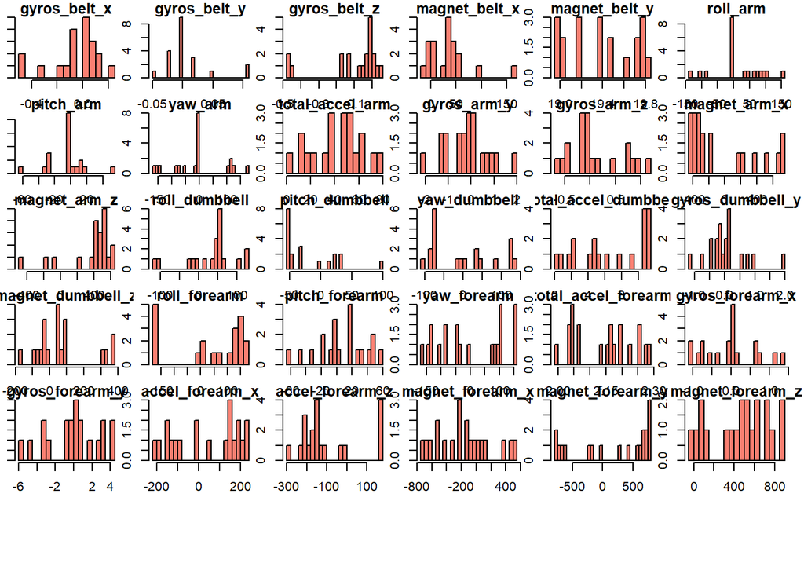

##### 2.2 QQ Plots

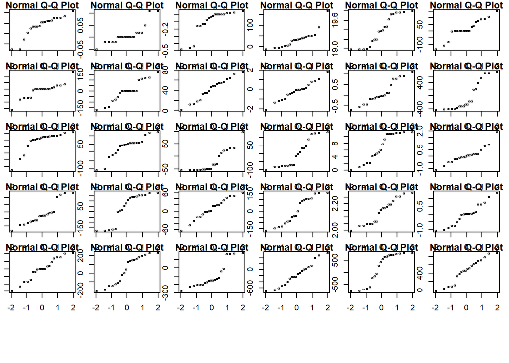

##### 2.3 Correlation Plot

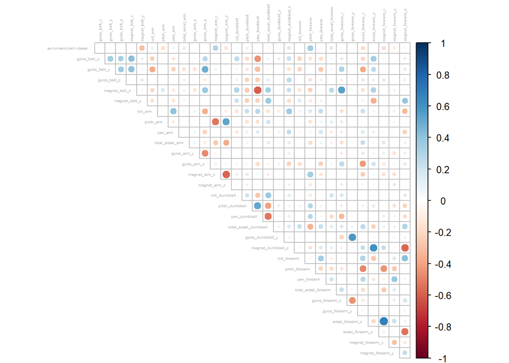

##### 2.5 Heirarchical Clustering

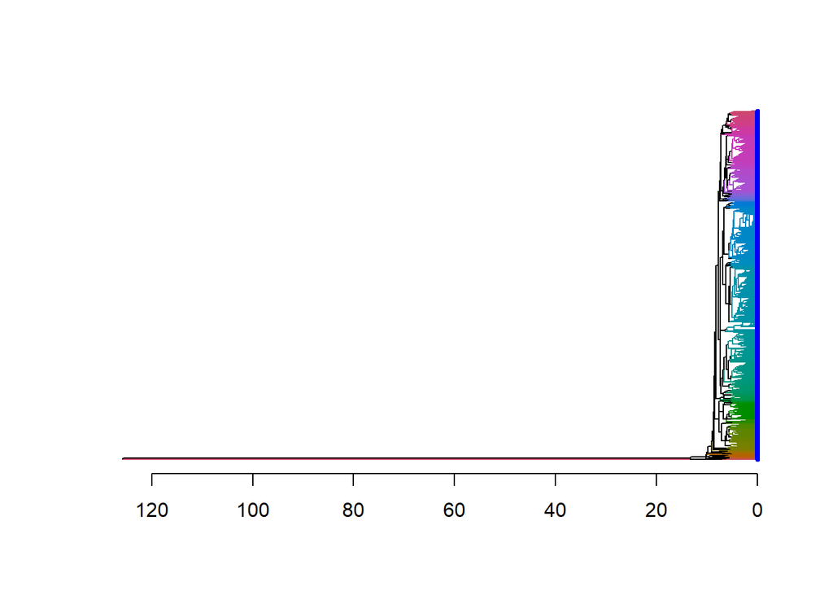

##### 2.6 K-Means Clustering

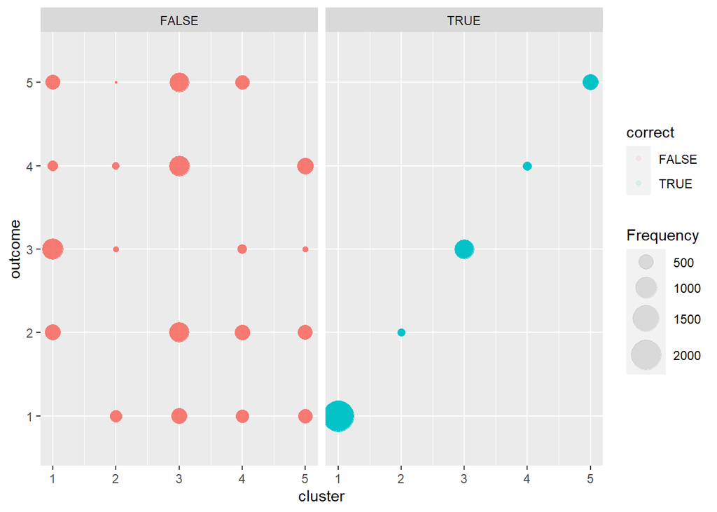

##### 2.7 Principal Components Analysis

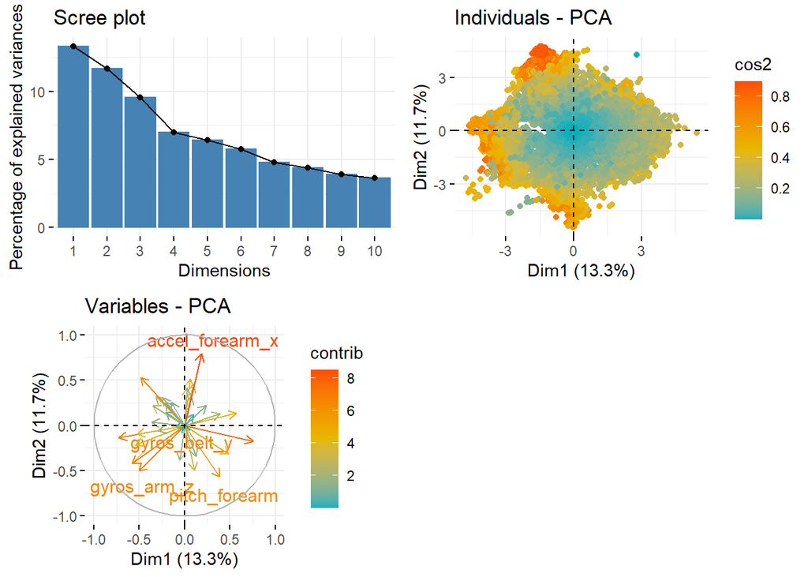